# 110-1 臺大 時空資料視覺化 Spatiotemporal Data Visualization HW2

R09228001 楊宇翔 台大地理碩二

10/1/2021

### 1.1 Using overlapped histogram (or density) for comparing the distributions of the prices of parking places between 華夏 and 住宅大樓。

# Interpretation:

### I generated two density graphs with ggplot2 package below. In the first graph, it is the overall picture and in the second graph, I zoom in to the overlapping area. They habe different peak and distribution but they overlap in somewhere.

```r
rm(list=ls())
setwd("~/Desktop/110-1/110-1 data visualization/week20930")
library(readxl)
s1=read_excel("s1.xls")
s2=read_excel("s2.xls")
s3=read_excel("s3.xls")
s4=read_excel("s4.xls")
d=rbind(s1,s2,s3,s4)

#install.packages("dplyr")
library(dplyr)
```

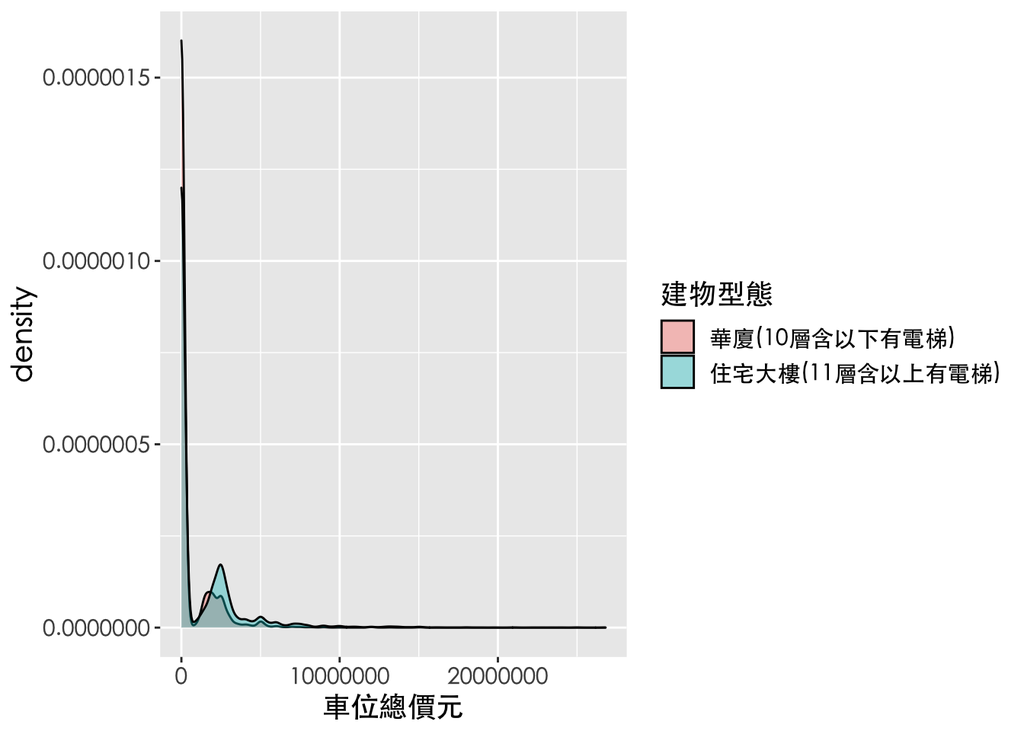

```r
df=d %>% select(土地位置建物門牌,建物型態,車位總價元)
df$車位總價元=as.numeric(df$車位總價元)
library(dplyr)
gb=df %>% filter(建物型態 %in% c("華廈(10層含以下有電梯)","住宅大樓(11層含以上有電梯)")) #%>% group_by(建物型態) %>% summarise(mean(車位總價元))
options(scipen = 999)
library(ggplot2)
ggplot(gb,aes(x=車位總價元,fill=建物型態))+
  geom_density(alpha=0.4)+
  theme(text=element_text(family="黑體-繁 中黑", size=14))
```

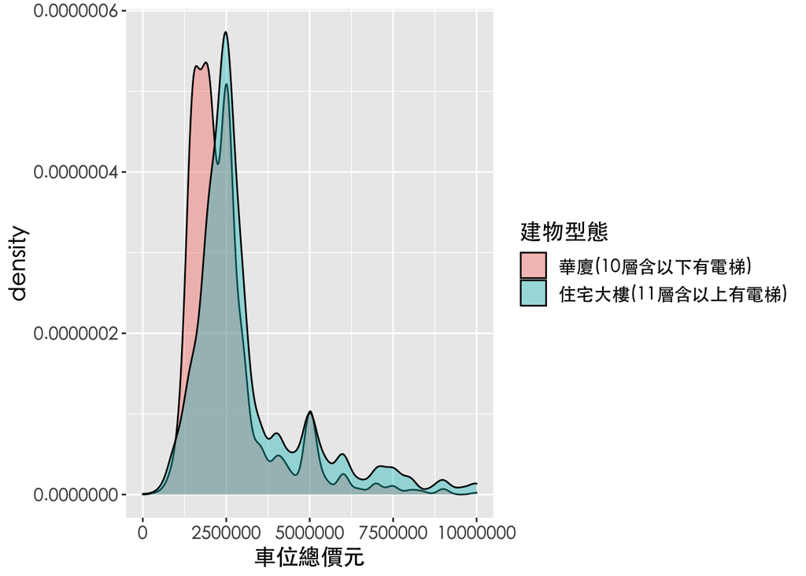

```r
ggplot(gb,aes(x=車位總價元,fill=建物型態))+
  geom_density(alpha=0.4)+
  theme(text=element_text(family="黑體-繁 中黑", size=14))+
  scale_x_continuous(limits=c(1,10000000))
```

### 1.2 Using ttest() to compare its differences of mean prices and summary the statistical results.

# Interpretation:

### In Welch Two Sample t-test, t value is -23.487, df is 14557 and p-value is < 0.00000000000000022.Because p-value < 0.05, it is statistically significant and we can deny HO. Accordingly, true difference in means is not equal to 0. In this senario, mean of parking price in 華廈(10層含以下有電梯) and 住宅大樓(11層含以上有電梯) is statistically difference.

```r
m=gb %>% filter(建物型態=="華廈(10層含以下有電梯)")
t=gb %>% filter(建物型態=="住宅大樓(11層含以上有電梯)")
t.test(m$車位總價元,t$車位總價元)
```

```
##
##  Welch Two Sample t-test
##
## data:  m$車位總價元 and t$車位總價元
## t = -23.487, df = 14557, p-value < 0.00000000000000022
## alternative hypothesis: true difference in means is not equal to 0
## 95 percent confidence interval:
##  -744909.9 -630151.5
## sample estimates:
## mean of x mean of y
##  479550.2 1167080.9
```

### 2. Using boxplot to compare the unit price (單價元) among different shifting level (移轉層次) and discuss whether the object with higher floor could have higher transaction prices?

### Note: you should describe the procedure ofhow you handle the column of shifting level (移轉層次)

# Interpretation:

### In general, the higher the floor of item is, the higher the unit price is. In another word,the object with higher floor could have higher transaction prices. Among this big picture, 1st floor has relatively high unit price than 2-4th floor.

```r
t1=as.data.frame(table(d$移轉層次))

#先刪除na
d2=d[which(!is.na(d$移轉層次)), ]
d2=d2[which(!is.na(d$單價元平方公尺)), ]

#地下
under=agrep("地下",d2$移轉層次)

#只能大概，先不要全分類
u=d2[under,]
u$floor=0

#地上
#只能大概，先不要全分類
up=d2[-under,]

up$移轉層次[is.na(up$移轉層次)]=0
for (i in 1:nrow(up)){
  if (up$移轉層次[i] =="一層") up$floor[i]=1
  else if (up$移轉層次[i] =="二層") up$floor[i]=1
  else if (up$移轉層次[i] =="三層") up$floor[i]=2
  else if (up$移轉層次[i] =="四層") up$floor[i]=2
  else if (up$移轉層次[i] =="五層") up$floor[i]=3
  else if (up$移轉層次[i] =="六層") up$floor[i]=3
  else if (up$移轉層次[i] =="七層") up$floor[i]=3
  else if (up$移轉層次[i] =="八層") up$floor[i]=3
  else if (up$移轉層次[i] =="九層") up$floor[i]=3
  else if (up$移轉層次[i] =="十層") up$floor[i]=4
  else if (up$移轉層次[i] =="十一層") up$floor[i]=4
  else if (up$移轉層次[i] =="十二層") up$floor[i]=4
  else if (up$移轉層次[i] =="十三層") up$floor[i]=4
  else if (up$移轉層次[i] =="十四層") up$floor[i]=4
  else if (up$移轉層次[i] =="十五層") up$floor[i]=5
  else if (up$移轉層次[i] =="十六層") up$floor[i]=5
  else if (up$移轉層次[i] =="十七層") up$floor[i]=5
  else if (up$移轉層次[i] =="十八層") up$floor[i]=5
  else if (up$移轉層次[i] =="十九層") up$floor[i]=5
  else if (up$移轉層次[i] =="二十層") up$floor[i]=6
    else if (up$移轉層次[i] =="二十ㄧ層") up$floor[i]=6
      else if (up$移轉層次[i] =="二十二層") up$floor[i]=6
        else if (up$移轉層次[i] =="二十三層") up$floor[i]=6
          else if (up$移轉層次[i] =="二十四層") up$floor[i]=6
           else if (up$移轉層次[i] =="二十五層") up$floor[i]=7
    else if (up$移轉層次[i] =="二十六層") up$floor[i]=7
      else if (up$移轉層次[i] =="二十七層") up$floor[i]=7
        else if (up$移轉層次[i] =="二十八層") up$floor[i]=7
          else if (up$移轉層次[i] =="二十九層") up$floor[i]=7
    else if (up$移轉層次[i] =="三十層") up$floor[i]=8
    else up$floor[i]=-999
}
table(up$floor)
```

```
##
## -999    1    2    3    4    5    6    7    8
## 5506 4284 5616 7003 2900  592  137   66    3
```

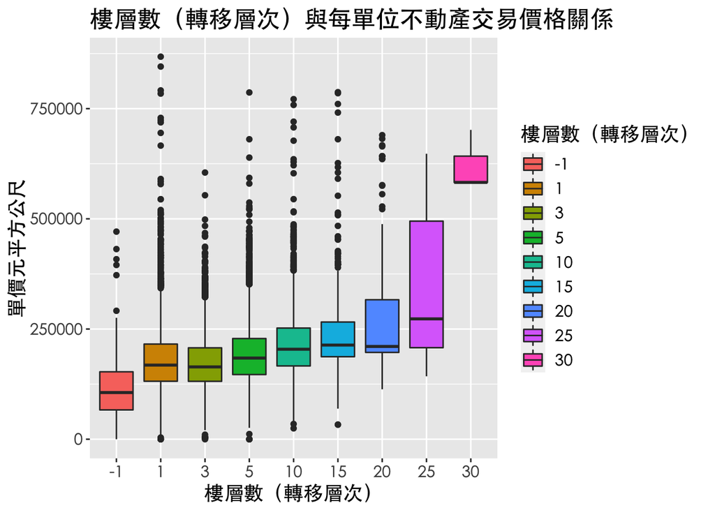

```r
up2=up[-which(up$floor==-999),]
data=rbind(u,up2)



library(dplyr)
data2=data %>% select(floor,單價元平方公尺)

data3=data2[which(!is.na(data2$單價元平方公尺)), ]
data3$單價元平方公尺=as.numeric(data3$單價元平方公尺)
data3$floor=as.factor(data3$floor)

for( i in 1:nrow(data3)){
  if (data3$floor[i]==0) data3$fl[i]=-1
    else if (data3$floor[i]==1) data3$fl[i]=1
    else if (data3$floor[i]==2) data3$fl[i]=3
    else if (data3$floor[i]==3) data3$fl[i]=5
    else if (data3$floor[i]==4) data3$fl[i]=10
    else if (data3$floor[i]==5) data3$fl[i]=15
    else if (data3$floor[i]==6) data3$fl[i]=20
    else if (data3$floor[i]==7) data3$fl[i]=25
    else if (data3$floor[i]==8) data3$fl[i]=30
}
data3$fl=as.factor(data3$fl)
#ggplot
ggplot(data3,aes(x=fl,y=單價元平方公尺,fill=fl))+
geom_boxplot()+ theme(text=element_text(family="黑體-繁 中黑", size=14))+labs(x="樓層數（轉移層次）",fill="樓層數（轉移層次）")+
  ggtitle("樓層數（轉移層次）與每單位不動產交易價格關係")
```

### 3. Using graphics to characterize the objects of which the unit price is outlier and compare among different districts of Taipei City.

##### Hint: Describe the characteristics of the objects with very high unit prices? And are these characteristics the same across Taipei City?

# Interpretation:

### I found out that “construction type”（建物型態）may be the characters for the unit price outlier (extermely high). I compared the group of outlier (742 items) and all the non-outlier item (20996 items), and made boxplot to show the distribution of data in each construction type. As show in boxplot below, we can see there are 2 type which is 2 highest value among all the construction type. The highest one is HOUSE （透天厝），the second one is store (店面(店鋪)). To sum up, In my own analysis, I found “construction type”（建物型態) may be realted to the unit price of property transaction especially in HOUSE （透天厝） and store (店面(店鋪)).

```r
#先刪除na
q=d[which(!is.na(d$單價元平方公尺)), ]

q$單價元平方公尺=as.numeric(q$單價元平方公尺)
```

```r
q=q[which(!is.na(q$單價元平方公尺)), ]
#summary(q$單價元平方公尺)
#boxplot(q$單價元平方公尺)
#par(family='STKaiti')
#hist(q$單價元平方公尺)


p=q %>% select(鄉鎮市區,都市土地使用分區,交易年月日,主要用途,建物型態,主要建材,建築完成年月,有無管理組織,單價元平方公尺,總樓層數) %>% na.omit()

# 找出 outlier
out <- boxplot.stats(p$單價元平方公尺)$out
out_ind <- which(p$單價元平方公尺 %in% c(out))
ot=p[out_ind,]
ot$class="outlier"
not=p[-out_ind,]
not$class="non-outlier"
df=rbind(ot,not)
colnames(df)
```

```
##  [1] "鄉鎮市區"         "都市土地使用分區" "交易年月日"       "主要用途"
##  [5] "建物型態"         "主要建材"         "建築完成年月"     "有無管理組織"
##  [9] "單價元平方公尺"   "總樓層數"         "class"
```

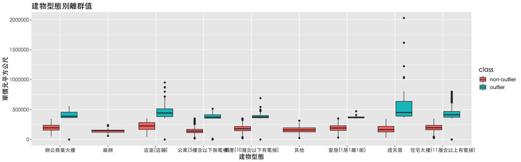

```r
ggplot(df,aes(x=建物型態,y=單價元平方公尺,fill=class))+
  geom_boxplot()+ theme(text=element_text(family="黑體-繁 中黑", size=14))+
  ggtitle("建物型態別離群值")
```

### To sum up, construction type may be related to the unit price and are not the same within Taipei city.

```r
house=df %>% filter(建物型態=="透天厝")
house
```

```
## # A tibble: 311 x 11
##    鄉鎮市區 都市土地使用分區 交易年月日 主要用途 建物型態 主要建材     建築完成年月
##    <chr>    <chr>            <chr>      <chr>    <chr>    <chr>        <chr>
##  1 北投區   商               1080922    住商用   透天厝   磚造         0751111
##  2 士林區   住               1081021    住家用   透天厝   加強磚造     0580510
##  3 北投區   商               1081016    住家用   透天厝   加強磚造     0560927
##  4 北投區   住               1081026    住家用   透天厝   加強磚造     0620515
##  5 北投區   住               1081215    住家用   透天厝   加強磚造     0570115
##  6 北投區   住               1081225    住家用   透天厝   鋼筋混凝土造 0620220
##  7 士林區   住               1081127    住家用   透天厝   加強磚造     0500315
##  8 士林區   住               1081201    住家用   透天厝   加強磚造     0500315
##  9 中正區   商               1081115    住商用   透天厝   鋼筋混凝土造 0550302
## 10 北投區   住               1081231    住家用   透天厝   加強磚造     0530605
## # … with 301 more rows, and 4 more variables: 有無管理組織 <chr>,
## #   單價元平方公尺 <dbl>, 總樓層數 <chr>, class <chr>
```

```r
store=df %>% filter(建物型態=="店面(店鋪)")
store
```

```
## # A tibble: 236 x 11
##    鄉鎮市區 都市土地使用分區 交易年月日 主要用途 建物型態   主要建材 建築完成年月
##    <chr>    <chr>            <chr>      <chr>    <chr>      <chr>    <chr>
##  1 大安區   其他             1080826    商業用   店面(店鋪) 鋼筋混…  0710227
##  2 信義區   住               1080822    住家用   店面(店鋪) 鋼筋混…  0600704
##  3 內湖區   住               1081027    住家用   店面(店鋪) 鋼筋混…  0770204
##  4 大安區   其他             1080921    商業用   店面(店鋪) 鋼筋混…  0701231
##  5 中山區   商               1081021    商業用   店面(店鋪) 鋼筋混…  0970312
##  6 松山區   住               1081111    住家用   店面(店鋪) 鋼筋混…  0680719
##  7 大安區   其他             1081106    商業用   店面(店鋪) 鋼筋混…  0731204
##  8 中正區   住               1081020    住家用   店面(店鋪) 鋼筋混…  0610627
##  9 大安區   住               1081029    住家用   店面(店鋪) 加強磚造 0560417
## 10 中山區   商               1081021    住商用   店面(店鋪) 鋼筋混…  0660121
## # … with 226 more rows, and 4 more variables: 有無管理組織 <chr>,
## #   單價元平方公尺 <dbl>, 總樓層數 <chr>, class <chr>
```

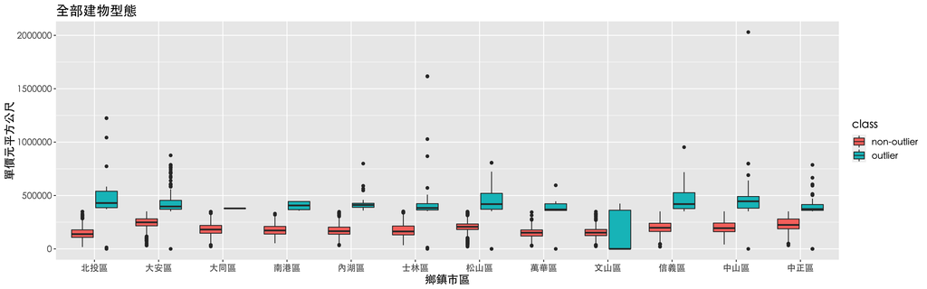

```r
ggplot(df,aes(x=鄉鎮市區,y=單價元平方公尺,fill=class))+
  geom_boxplot()+ theme(text=element_text(family="黑體-繁 中黑", size=14))+
  ggtitle("全部建物型態")
```

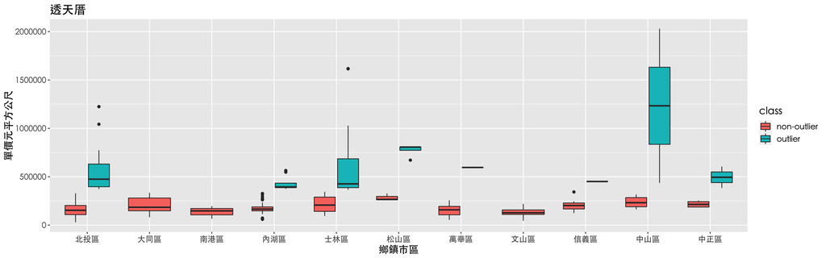

```r
ggplot(house,aes(x=鄉鎮市區,y=單價元平方公尺,fill=class))+
  geom_boxplot()+ theme(text=element_text(family="黑體-繁 中黑", size=14))+
  ggtitle("透天厝")
```

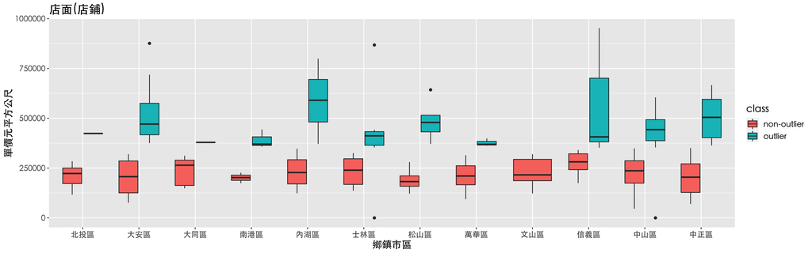

```r
ggplot(store,aes(x=鄉鎮市區,y=單價元平方公尺,fill=class))+
  geom_boxplot()+ theme(text=element_text(family="黑體-繁 中黑", size=14))+
  ggtitle("店面(店鋪)")
```